# Data 607: Project 3

VINAYAK PATEL

October 19, 2018

# **Abstract**

For the project 3, we have decided to conduct survey and analyze the response to find out the necessary soft-skills, and technical skills. Also Which programming language is need to learn first, and which programming language is necessary to be successful Data Scientist so we have decieded .

# **Data Source**

## Context

Kaggle already has the wide survey available for the Data science and Machine learning with more than 16000 respondents but data scientist also needs to know how to conduct survey in order to generate own datasets.

## Methodology

The survey was taken during October 17 to October 20th. Most of the questions was not required because they can submit most information survey as many as they can and didn’t forced to select unnecessary and wrong options.

## platform used

This survey was conducted using Google Forms. Also, most of the respondents were from LinkedIn group: “Data Scientist & Analyst”, “Database Administrator (+5000 DBAs from around the world) Join now!”, and “Datacamp Community” Slack Channel.

# **Environment Prep**

```r
if (!require('ggplot2')) install.packages('ggplot2')
if (!require('car')) install.packages('car')
if (!require('rlist')) install.packages('rlist')
if (!require('tidyverse')) install.packages('tidyverse')
if (!require('likert')) install.packages('likert')
```

# **Importing data**

```r
# Import survey data
rawData <- read.csv("https://raw.githubusercontent.com/Vinayak234/SPS_DATA_607/master/SPS_DATA_607/Project_3/To%20find%20Most%20Valued%20Data%20Science%20Skills.csv", stringsAsFactors = FALSE, header = TRUE, na.strings = c("", "NA"))

rawData
```

| Timestamp | Gender | Select.the.country.you.currently.live.in. | Are.you.related.to.IT.Profession. | What.s.your.age. | Are.you.currently.enrolled.as.a.student.at.a.degree.granting.school. | Which.highest.level.of.formal.education.have.you.attained. | Which.best.describes.your.undergraduate.major. | Are.you.currently.focused.on.learning.data.science.skills.either.formally.or.informally. | What.s.your.current.employment.status. | Select.the.option.that.s.most.similar.to.your.current.job.professional.title..or.most.recent.title.if.retired. | How.long.have.you.been.learning.data.science.and.or.working.in.the.data.science.field. | How.useful.did.you.find.these.platforms...resources.for.learning.data.science.skills...Blogs. | How.useful.did.you.find.these.platforms...resources.for.learning.data.science.skills...College.University. | How.useful.did.you.find.these.platforms...resources.for.learning.data.science.skills...Personal.Projects. | How.useful.did.you.find.these.platforms...resources.for.learning.data.science.skills...Online.courses..coursera..udemy..edx..etc... | How.useful.did.you.find.these.platforms...resources.for.learning.data.science.skills...Friends.network. | How.useful.did.you.find.these.platforms...resources.for.learning.data.science.skills...Company.internal.community. | How.useful.did.you.find.these.platforms...resources.for.learning.data.science.skills...YouTube.Videos. | How.useful.did.you.find.these.platforms...resources.for.learning.data.science.skills...Textbook. | What.programming.language.would.you.recommend.most.to.learn.first.to.new.data.scientist. | What.programming.language.would.you.recommend.must.need.to.have.as.data.scientist. | How.important.do.you.think.the.below.skills.or.certifications.are.in.getting.a.data.science.job...Amazon.Machine.Learning. | How.important.do.you.think.the.below.skills.or.certifications.are.in.getting.a.data.science.job...Big.Data. | How.important.do.you.think.the.below.skills.or.certifications.are.in.getting.a.data.science.job...College.Degree. | How.important.do.you.think.the.below.skills.or.certifications.are.in.getting.a.data.science.job...Data.Visualizations. | How.important.do.you.think.the.below.skills.or.certifications.are.in.getting.a.data.science.job...Enterprise.Tools. | How.important.do.you.think.the.below.skills.or.certifications.are.in.getting.a.data.science.job...Google.Cloud. | How.important.do.you.think.the.below.skills.or.certifications.are.in.getting.a.data.science.job...Hadoop.Hive.Pig. | How.important.do.you.think.the.below.skills.or.certifications.are.in.getting.a.data.science.job...IBM.SPSS. | … |
| --- | --- | --- | --- | --- | --- | --- | --- | --- | --- | --- | --- | --- | --- | --- | --- | --- | --- | --- | --- | --- | --- | --- | --- | --- | --- | --- | --- | --- | --- | --- |
| 10/17/2018 5:40 | Male | United States | Yes | 24 | Yes | Master's degree | A health science | Yes, but data science is a small part of what I'm focused on learning | Not employed, but looking for work | NA | < 1 Year | Somewhat useful | NA | Somewhat useful | Very useful | Very useful | Not at all useful | Somewhat useful | Not at all useful | Python | Python | NA | Unnecessary | Nice to have | Unnecessary | Unnecessary | NA | NA | NA | … |
| 10/17/2018 8:13 | Male | United States | No | NA | NA | NA | NA | NA | NA | NA | NA | NA | NA | NA | NA | NA | NA | NA | NA | NA | NA | NA | NA | NA | NA | NA | NA | NA | NA | … |
| 10/17/2018 13:16 | Female | United States | Maybe | 44 | No | Master's degree | Mathematics or statistics | Yes, I'm focused on learning mostly data science skills | Employed full-time | Data Scientist | > 10 years | Somewhat useful | Very useful | Somewhat useful | Very useful | Very useful | Very useful | Somewhat useful | Somewhat useful | R | R | Nice to have | Necessary | Necessary | Necessary | Nice to have | Nice to have | Nice to have | Nice to have | … |
| 10/17/2018 13:21 | Female | United States | Yes | 37 | No | NA | Information Technology, Networking, or System Administration | Yes, but data science is a small part of what I'm focused on learning | Employed full-time | NA | 5 - 10 years | NA | Very useful | NA | NA | Not at all useful | NA | NA | NA | Python | Python | Nice to have | Nice to have | Nice to have | Nice to have | Nice to have | Nice to have | Unnecessary | Unnecessary | … |
| 10/17/2018 13:25 | Male | United States | Yes | 32 | No | Bachelor's degree | Finance | Yes, I'm focused on learning mostly data science skills | Employed full-time | Engineer | 1 - 2 years | Somewhat useful | Somewhat useful | Very useful | Somewhat useful | Not Very useful | Not Very useful | Somewhat useful | Not at all useful | Python | Python | Nice to have | Nice to have | Nice to have | Nice to have | Nice to have | Nice to have | Unnecessary | Unnecessary | … |
| 10/17/2018 13:29 | Male | Canada | Yes | 28 | Yes | Master's degree | Engineering (non-computer focused) | Yes, I'm focused on learning mostly data science skills | Not employed, but looking for work | NA | 3 - 5 years | Somewhat useful | Somewhat useful | NA | Very useful | Somewhat useful | Somewhat useful | Very useful | NA | R | R | Nice to have | Nice to have | Nice to have | Nice to have | Nice to have | Nice to have | Unnecessary | Unnecessary | … |
| 10/17/2018 13:29 | Male | United States | Yes | 32 | No | Bachelor's degree | Finance | Yes, I'm focused on learning mostly data science skills | Employed full-time | Engineer | 1 - 2 years | Very useful | Somewhat useful | Very useful | Somewhat useful | Not Very useful | Not Very useful | Somewhat useful | Not at all useful | Python | Python | Nice to have | Nice to have | Nice to have | Nice to have | Nice to have | Nice to have | Unnecessary | Unnecessary | … |
| 10/17/2018 13:29 | Male | United States | Yes | 58 | No | Master's degree | Mathematics or statistics | No, I am not focused on learning data science skills | Independent contractor, freelancer, or self-employed | DBA/Database Engineer | > 10 years | NA | NA | Somewhat useful | Very useful | Very useful | Somewhat useful | Very useful | Very useful | R | R | Nice to have | Nice to have | Nice to have | Nice to have | Nice to have | Nice to have | Unnecessary | Unnecessary | … |
| 10/17/2018 13:38 | Male | New Zealand | Yes | 33 | No | Doctoral degree | Information Technology, Networking, or System Administration | Yes, but data science is a small part of what I'm focused on learning | Employed full-time | Scientist/Researcher | 1 - 2 years | Not Very useful | Very useful | NA | Not Very useful | NA | Not at all useful | Somewhat useful | NA | SAS | SAS | Unnecessary | Nice to have | Necessary | Necessary | Nice to have | Unnecessary | Unnecessary | Unnecessary | … |
| 10/17/2018 13:48 | Female | United States | Yes | 30 | Yes | Master's degree | Computer Science | Yes, I'm focused on learning mostly data science skills | Not employed, but looking for work | NA | < 1 Year | Very useful | Very useful | Somewhat useful | Very useful | Somewhat useful | Not at all useful | Somewhat useful | Not at all useful | Python | Python | Nice to have | Necessary | Necessary | Necessary | Nice to have | Nice to have | Nice to have | Nice to have | … |

[output cut: 61 more lines]

**Clean data**

```r
# Dropping none IT professionals records
clean_rawData<- rawData[!grepl("No", rawData$Are.you.related.to.IT.Profession.),]

#Drop column not needed
drops_c <- c("Timestamp","Are.you.related.to.IT.Profession.")
clean_rawData<-clean_rawData[ , !(names(clean_rawData) %in% drops_c)]

#Short name for column name
Short_name <- c("Gender","Country","Age","Are you in School","Eduction","Major","Are you learning data science skill","Emplyment Status", "Title", "Experience", "Blogs", "College","Projects", "Online Course", "Friends", "Co-workers", "Youtube","Textbooks","First language","must language","Amazon Machine Learning","Big Data","College Degree","Data Visualizations","Enterprise Tools","Google Cloud","Hadoop/Hive/Pig","IBM SPSS","Java","Microsoft Excel","NoSQL","Oracle Data Mining","Python","R","Relational data","SAS","SQL","Tableau","Intellectual curiosity","Business acumen", "Communication skills", "Teamwork", "Collaboration", "Creative Thinking","Problem Solving", "Active Learning","Perceptiveness","Interpersonal Skills","Generating Hypotheses")

colnames(clean_rawData) <- Short_name
head(clean_rawData)
```

|  | Gender | Country | Age | Are you in School | Eduction | Major | Are you learning data science skill | Emplyment Status | Title | Experience | Blogs | College | Projects | Online Course | Friends | Co-workers | Youtube | Textbooks | First language | must language | Amazon Machine Learning | Big Data | College Degree | Data Visualizations | Enterprise Tools | Google Cloud | Hadoop/Hive/Pig | IBM SPSS | Java | … |
| --- | --- | --- | --- | --- | --- | --- | --- | --- | --- | --- | --- | --- | --- | --- | --- | --- | --- | --- | --- | --- | --- | --- | --- | --- | --- | --- | --- | --- | --- | --- |
| 1 | Male | United States | 24 | Yes | Master's degree | A health science | Yes, but data science is a small part of what I'm focused on learning | Not employed, but looking for work | NA | < 1 Year | Somewhat useful | NA | Somewhat useful | Very useful | Very useful | Not at all useful | Somewhat useful | Not at all useful | Python | Python | NA | Unnecessary | Nice to have | Unnecessary | Unnecessary | NA | NA | NA | Unnecessary | … |
| 3 | Female | United States | 44 | No | Master's degree | Mathematics or statistics | Yes, I'm focused on learning mostly data science skills | Employed full-time | Data Scientist | > 10 years | Somewhat useful | Very useful | Somewhat useful | Very useful | Very useful | Very useful | Somewhat useful | Somewhat useful | R | R | Nice to have | Necessary | Necessary | Necessary | Nice to have | Nice to have | Nice to have | Nice to have | Nice to have | … |
| 4 | Female | United States | 37 | No | NA | Information Technology, Networking, or System Administration | Yes, but data science is a small part of what I'm focused on learning | Employed full-time | NA | 5 - 10 years | NA | Very useful | NA | NA | Not at all useful | NA | NA | NA | Python | Python | Nice to have | Nice to have | Nice to have | Nice to have | Nice to have | Nice to have | Unnecessary | Unnecessary | Unnecessary | … |
| 5 | Male | United States | 32 | No | Bachelor's degree | Finance | Yes, I'm focused on learning mostly data science skills | Employed full-time | Engineer | 1 - 2 years | Somewhat useful | Somewhat useful | Very useful | Somewhat useful | Not Very useful | Not Very useful | Somewhat useful | Not at all useful | Python | Python | Nice to have | Nice to have | Nice to have | Nice to have | Nice to have | Nice to have | Unnecessary | Unnecessary | Unnecessary | … |
| 6 | Male | Canada | 28 | Yes | Master's degree | Engineering (non-computer focused) | Yes, I'm focused on learning mostly data science skills | Not employed, but looking for work | NA | 3 - 5 years | Somewhat useful | Somewhat useful | NA | Very useful | Somewhat useful | Somewhat useful | Very useful | NA | R | R | Nice to have | Nice to have | Nice to have | Nice to have | Nice to have | Nice to have | Unnecessary | Unnecessary | Unnecessary | … |
| 7 | Male | United States | 32 | No | Bachelor's degree | Finance | Yes, I'm focused on learning mostly data science skills | Employed full-time | Engineer | 1 - 2 years | Very useful | Somewhat useful | Very useful | Somewhat useful | Not Very useful | Not Very useful | Somewhat useful | Not at all useful | Python | Python | Nice to have | Nice to have | Nice to have | Nice to have | Nice to have | Nice to have | Unnecessary | Unnecessary | Unnecessary | … |

# **Analysis**

## Gender, Demography, and Age Information

**We are looking to find out gender ratio, demograpghy, and age information**

```r
DataAge <- clean_rawData%>%
  select(Age) %>%
  filter(Age!='NA') %>%
  group_by(Age) %>%
  summarise(count=n()) %>%
  arrange(desc(count))
head(DataAge, n=5)
```

| Age | count |
| --- | --- |
| 24 | 5 |
| 29 | 5 |
| 30 | 5 |
| 27 | 4 |
| 32 | 4 |

```r
Gender_ratio <- clean_rawData%>%
  select(Gender)%>%
  group_by(Gender)%>%
  summarise(count=n())%>%
  mutate(percent = (count / sum(count)) * 100) %>%
  arrange(desc(count))

Gender_ratio
```

| Gender | count | percent |
| --- | --- | --- |
| Male | 51 | 73.91304 |
| Female | 18 | 26.08696 |

```r
#to see how many of the participants were male or female by their age for the graph
DataGender <- clean_rawData%>%
  select(Age,Gender) %>%
  filter(trimws(clean_rawData$Country)!='',Age!='NA') %>%
  group_by(Age,Gender) %>%
  summarise(count=n()) %>%
  arrange(desc(count))
```

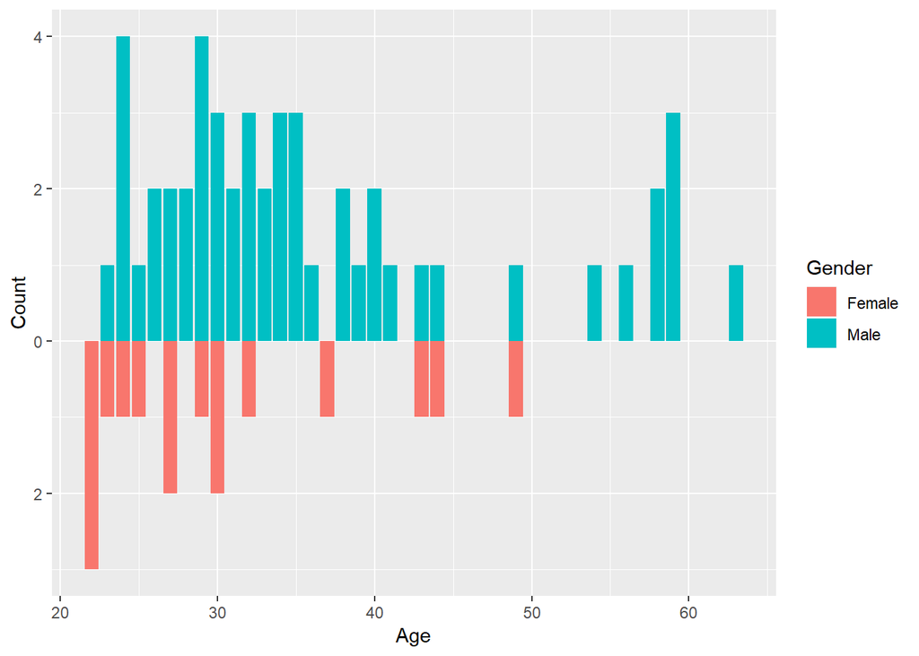

```r
# Plot
ggplot(data = DataGender,
       mapping = aes(x = Age, fill = Gender,
                     y = ifelse(test = Gender == "Female",
                                yes = -count, no = count)))+
  geom_bar(stat = "identity") +
  scale_y_continuous(labels = abs) +
  labs(y="Count")
```

**Results**

From the findings, we can see the Majority of the participants Age are **24**, **29**,**30** and there are **5** from each Ages.

Based on participants gender, we can see the Majority is **Male**. They are **73.9130435** percent compare to **Female** which are only **26.0869565** percent.

**Demography**

```r
DemoGraphicsData <- clean_rawData %>%
  group_by(Country)%>% # Group by country
  summarise(count=n()) %>%# Count how many respondents selected each option
  mutate(percent = (count / sum(count)) * 100) %>%
  arrange(desc(count))# Arrange the counts in descending order

DemoGraphicsData
```

| Country | count | percent |
| --- | --- | --- |
| United States | 39 | 56.521739 |
| India | 10 | 14.492754 |
| United Kingdom | 6 | 8.695652 |
| Canada | 5 | 7.246377 |
| Russia | 2 | 2.898551 |
| Australia | 1 | 1.449275 |
| France | 1 | 1.449275 |
| Germany | 1 | 1.449275 |
| Mexico | 1 | 1.449275 |
| Netherlands | 1 | 1.449275 |

[output cut: 2 more lines]

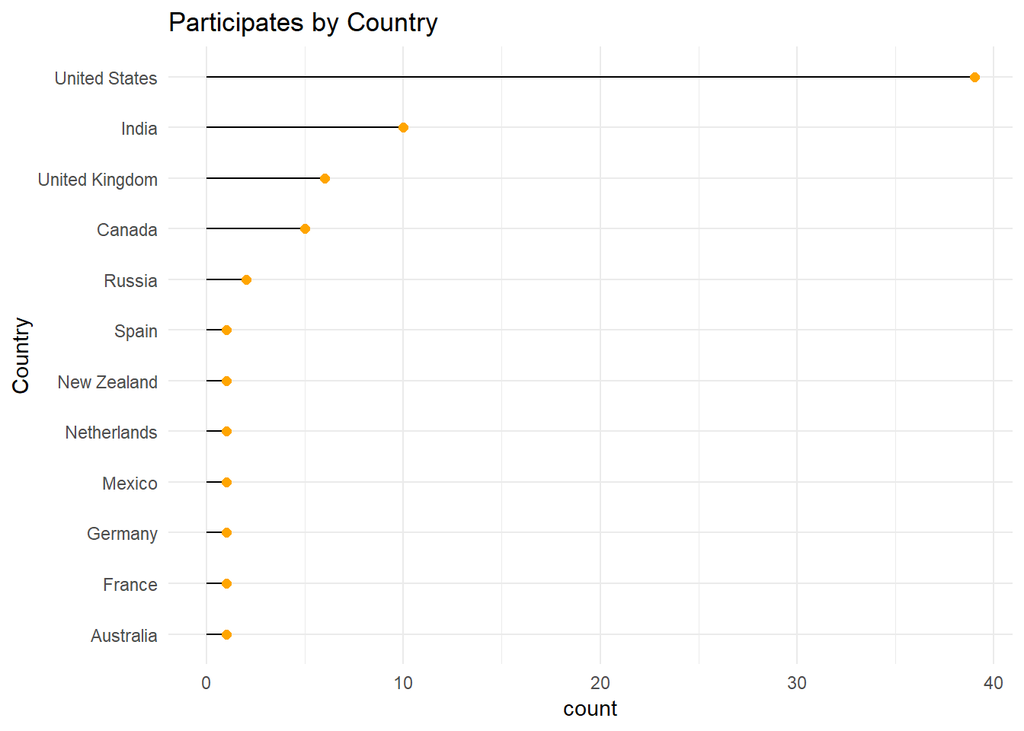

```r
#plot graph
DemoGraphicsData[] %>%
  arrange(count) %>%
  mutate(Country=factor(Country, levels=Country)) %>%
  ggplot( aes(x=Country, y=count)) +
    geom_segment( aes(xend=Country, yend=0)) +
    geom_point( size=2, color="orange") +
    coord_flip() + labs(title="Participates by Country")+
    theme_minimal()
```

**Results**

Based on participants country, we can see that there are **39** participants from **United States** and at the seconds place, there are **10** participants from **India**. **United States** is the majority by **56.5217391** of the all participants in survey.

## Programming language

**Most recommend Programming language**

We had asked participant to recommend the programming language, and we also asked them which programming language is necessary to know as data scientist

```r
# to findout most recommend language

First_language <- clean_rawData %>%
    # Remove any rows where the respondent didn't answer the question
    filter(trimws(clean_rawData$`First language`)!='')%>%
    # Group by the responses to the question
    group_by(`First language`) %>%
    # Count how many respondents selected each option
    summarise(count = n()) %>%
    # Calculate what percent of respondents selected each option
    mutate(percent = (count / sum(count)) * 100) %>%
    # Arrange the counts in descending order
    arrange(desc(count))

First_language
```

| First language | count | percent |
| --- | --- | --- |
| Python | 38 | 56.716418 |
| R | 18 | 26.865672 |
| SQL | 4 | 5.970149 |
| Java | 2 | 2.985075 |
| SAS | 2 | 2.985075 |
| C/C++/C# | 1 | 1.492537 |
| Matlab | 1 | 1.492537 |
| Other | 1 | 1.492537 |

**Must needed Programming language**

```r
# to findout have to learn language

Neccecery_language <- clean_rawData %>%
  # Remove any rows where the respondent didn't answer the question
  filter(trimws(clean_rawData$`must language`)!='')%>%
  # Group by the responses to the question
  group_by(`must language`) %>%
  # Count how many respondents selected each option
  summarise(count = n()) %>%
  # Calculate what percent of respondents selected each option
  mutate(percent = (count / sum(count)) * 100) %>%
  # Arrange the counts in descending order
  arrange(desc(count))

Neccecery_language
```

| must language | count | percent |
| --- | --- | --- |
| Python | 34 | 50.746269 |
| R | 22 | 32.835821 |
| SQL | 5 | 7.462687 |
| Java | 2 | 2.985075 |
| SAS | 2 | 2.985075 |
| Matlab | 1 | 1.492537 |
| Other | 1 | 1.492537 |

**Results**

As a result, it is clear that **Python** is most recommended programming language for Data Scientist. There are **56.7164179** percent participants who recommend the language. And, Second most recommended programming language is **R** with **26.8656716** percent votes.

Also, result suggests that **50.7462687** percent of participants thinks **Python** is must needed language. Second is **R** with **32.8358209** percent.

## To find out helpfulness of diffenent way to learn

```r
clean_rawData_helpful <- clean_rawData %>%
  select(Blogs:Textbooks)

clean_rawData_helpful
```

|  | Blogs | College | Projects | Online Course | Friends | Co-workers | Youtube | Textbooks |
| --- | --- | --- | --- | --- | --- | --- | --- | --- |
| 1 | Somewhat useful | NA | Somewhat useful | Very useful | Very useful | Not at all useful | Somewhat useful | Not at all useful |
| 3 | Somewhat useful | Very useful | Somewhat useful | Very useful | Very useful | Very useful | Somewhat useful | Somewhat useful |
| 4 | NA | Very useful | NA | NA | Not at all useful | NA | NA | NA |
| 5 | Somewhat useful | Somewhat useful | Very useful | Somewhat useful | Not Very useful | Not Very useful | Somewhat useful | Not at all useful |
| 6 | Somewhat useful | Somewhat useful | NA | Very useful | Somewhat useful | Somewhat useful | Very useful | NA |
| 7 | Very useful | Somewhat useful | Very useful | Somewhat useful | Not Very useful | Not Very useful | Somewhat useful | Not at all useful |
| 8 | NA | NA | Somewhat useful | Very useful | Very useful | Somewhat useful | Very useful | Very useful |
| 9 | Not Very useful | Very useful | NA | Not Very useful | NA | Not at all useful | Somewhat useful | NA |
| 10 | Very useful | Very useful | Somewhat useful | Very useful | Somewhat useful | Not at all useful | Somewhat useful | Not at all useful |
| 11 | NA | Somewhat useful | Somewhat useful | NA | NA | Not Very useful | NA | NA |

[output cut: 59 more lines]

```r
#clean record
clean_rawData_helpful<- na.omit(clean_rawData_helpful)

clean_rawData_helpful[] <- lapply(clean_rawData_helpful, factor)
clean_rawData_helpful
```

|  | Blogs | College | Projects | Online Course | Friends | Co-workers | Youtube | Textbooks |
| --- | --- | --- | --- | --- | --- | --- | --- | --- |
| 3 | Somewhat useful | Very useful | Somewhat useful | Very useful | Very useful | Very useful | Somewhat useful | Somewhat useful |
| 5 | Somewhat useful | Somewhat useful | Very useful | Somewhat useful | Not Very useful | Not Very useful | Somewhat useful | Not at all useful |
| 7 | Very useful | Somewhat useful | Very useful | Somewhat useful | Not Very useful | Not Very useful | Somewhat useful | Not at all useful |
| 10 | Very useful | Very useful | Somewhat useful | Very useful | Somewhat useful | Not at all useful | Somewhat useful | Not at all useful |
| 12 | Very useful | Very useful | Very useful | Very useful | Very useful | Very useful | Very useful | Very useful |
| 13 | Somewhat useful | Somewhat useful | Very useful | Very useful | Not at all useful | Not Very useful | Very useful | Somewhat useful |
| 15 | Somewhat useful | Somewhat useful | Not at all useful | Somewhat useful | Somewhat useful | Very useful | Very useful | Somewhat useful |
| 16 | Somewhat useful | Not at all useful | Very useful | Very useful | Somewhat useful | Not Very useful | Somewhat useful | Somewhat useful |
| 18 | Not Very useful | Very useful | Very useful | Very useful | Not Very useful | Not Very useful | Somewhat useful | Somewhat useful |
| 22 | Somewhat useful | Somewhat useful | Somewhat useful | Somewhat useful | Somewhat useful | Not at all useful | Somewhat useful | Somewhat useful |

[output cut: 25 more lines]

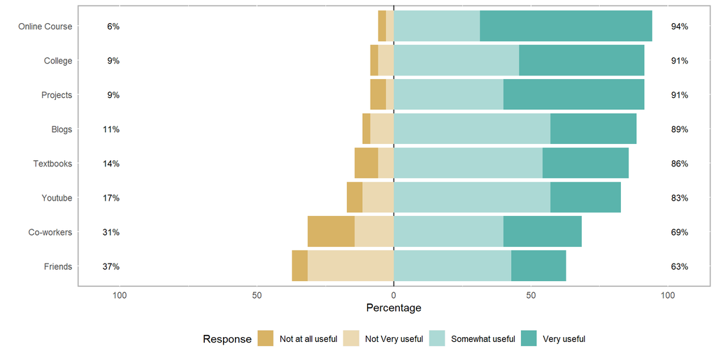

```r
# helpfull the plot
helpful_chart <- likert(clean_rawData_helpful)
plot(helpful_chart)
```

```r
df.v<- summary(helpful_chart) #for references in result
```

**Results**

Analysis on the effectiveness of learning, it clear that **Online Course** is very useful way to learn. It is topping the table with **94.2857143** It also suggest that **College** and **Projects** are also around **91.4285714** percent.

## Technical Skills/tools needed to know as data scienticst

Here, we are trying to find out the Most valuable Technical skills/ tool which needed to be successful Data Scientist.

```r
Techdata <- clean_rawData %>%
  select(`Amazon Machine Learning`:Tableau)

Techdata<- na.omit(Techdata)
Techdata
```

|  | Amazon Machine Learning | Big Data | College Degree | Data Visualizations | Enterprise Tools | Google Cloud | Hadoop/Hive/Pig | IBM SPSS | Java | Microsoft Excel | NoSQL | Oracle Data Mining | Python | R | Relational data | SAS | SQL | Tableau |
| --- | --- | --- | --- | --- | --- | --- | --- | --- | --- | --- | --- | --- | --- | --- | --- | --- | --- | --- |
| 3 | Nice to have | Necessary | Necessary | Necessary | Nice to have | Nice to have | Nice to have | Nice to have | Nice to have | Necessary | Nice to have | Nice to have | Necessary | Necessary | Necessary | Nice to have | Necessary | Necessary |
| 4 | Nice to have | Nice to have | Nice to have | Nice to have | Nice to have | Nice to have | Unnecessary | Unnecessary | Unnecessary | Nice to have | Nice to have | Nice to have | Necessary | Nice to have | Nice to have | Nice to have | Necessary | Nice to have |
| 5 | Nice to have | Nice to have | Nice to have | Nice to have | Nice to have | Nice to have | Unnecessary | Unnecessary | Unnecessary | Nice to have | Nice to have | Unnecessary | Necessary | Nice to have | Necessary | Nice to have | Necessary | Nice to have |
| 6 | Nice to have | Nice to have | Nice to have | Nice to have | Nice to have | Nice to have | Unnecessary | Unnecessary | Unnecessary | Nice to have | Nice to have | Unnecessary | Necessary | Nice to have | Necessary | Unnecessary | Necessary | Nice to have |
| 7 | Nice to have | Nice to have | Nice to have | Nice to have | Nice to have | Nice to have | Unnecessary | Unnecessary | Unnecessary | Nice to have | Nice to have | Unnecessary | Necessary | Nice to have | Necessary | Nice to have | Necessary | Nice to have |
| 8 | Nice to have | Nice to have | Nice to have | Nice to have | Nice to have | Nice to have | Unnecessary | Unnecessary | Unnecessary | Nice to have | Nice to have | Unnecessary | Necessary | Necessary | Necessary | Nice to have | Necessary | Nice to have |
| 9 | Unnecessary | Nice to have | Necessary | Necessary | Nice to have | Unnecessary | Unnecessary | Unnecessary | Nice to have | Necessary | Unnecessary | Nice to have | Necessary | Nice to have | Unnecessary | Necessary | Necessary | Nice to have |
| 10 | Nice to have | Necessary | Necessary | Necessary | Nice to have | Nice to have | Nice to have | Nice to have | Nice to have | Necessary | Nice to have | Nice to have | Necessary | Necessary | Unnecessary | Nice to have | Necessary | Necessary |
| 11 | Nice to have | Necessary | Nice to have | Necessary | Nice to have | Nice to have | Necessary | Unnecessary | Unnecessary | Necessary | Nice to have | Nice to have | Necessary | Nice to have | Necessary | Nice to have | Necessary | Nice to have |
| 12 | Nice to have | Necessary | Nice to have | Necessary | Nice to have | Nice to have | Necessary | Unnecessary | Unnecessary | Necessary | Nice to have | Nice to have | Necessary | Necessary | Necessary | Nice to have | Necessary | Nice to have |

[output cut: 39 more lines]

```r
Techdata[ ,1:18]  <- lapply(Techdata[ ,1:18],
                             FUN = function(x) Recode(x, "'Nice to have' =1 ;'Necessary'=2 ;'Unnecessary' = 0"))

Techdata
```

|  | Amazon Machine Learning | Big Data | College Degree | Data Visualizations | Enterprise Tools | Google Cloud | Hadoop/Hive/Pig | IBM SPSS | Java | Microsoft Excel | NoSQL | Oracle Data Mining | Python | R | Relational data | SAS | SQL | Tableau |
| --- | --- | --- | --- | --- | --- | --- | --- | --- | --- | --- | --- | --- | --- | --- | --- | --- | --- | --- |
| 3 | 1 | 2 | 2 | 2 | 1 | 1 | 1 | 1 | 1 | 2 | 1 | 1 | 2 | 2 | 2 | 1 | 2 | 2 |
| 4 | 1 | 1 | 1 | 1 | 1 | 1 | 0 | 0 | 0 | 1 | 1 | 1 | 2 | 1 | 1 | 1 | 2 | 1 |
| 5 | 1 | 1 | 1 | 1 | 1 | 1 | 0 | 0 | 0 | 1 | 1 | 0 | 2 | 1 | 2 | 1 | 2 | 1 |
| 6 | 1 | 1 | 1 | 1 | 1 | 1 | 0 | 0 | 0 | 1 | 1 | 0 | 2 | 1 | 2 | 0 | 2 | 1 |
| 7 | 1 | 1 | 1 | 1 | 1 | 1 | 0 | 0 | 0 | 1 | 1 | 0 | 2 | 1 | 2 | 1 | 2 | 1 |
| 8 | 1 | 1 | 1 | 1 | 1 | 1 | 0 | 0 | 0 | 1 | 1 | 0 | 2 | 2 | 2 | 1 | 2 | 1 |
| 9 | 0 | 1 | 2 | 2 | 1 | 0 | 0 | 0 | 1 | 2 | 0 | 1 | 2 | 1 | 0 | 2 | 2 | 1 |
| 10 | 1 | 2 | 2 | 2 | 1 | 1 | 1 | 1 | 1 | 2 | 1 | 1 | 2 | 2 | 0 | 1 | 2 | 2 |
| 11 | 1 | 2 | 1 | 2 | 1 | 1 | 2 | 0 | 0 | 2 | 1 | 1 | 2 | 1 | 2 | 1 | 2 | 1 |
| 12 | 1 | 2 | 1 | 2 | 1 | 1 | 2 | 0 | 0 | 2 | 1 | 1 | 2 | 2 | 2 | 1 | 2 | 1 |

[output cut: 39 more lines]

```r
temp1 <- names(Techdata)
temp2<- list(colSums(Techdata))

temp2<- data.frame(matrix(unlist(colSums(Techdata)), byrow=T))

scale <- cbind(temp1,temp2)
names(scale)[1] <-"Tech_Skill"
names(scale)[2] <-"Rank"

scale <- scale %>%
  arrange(desc(Rank))
scale
```

| Tech_Skill | Rank |
| --- | --- |
| SQL | 94 |
| Python | 91 |
| Data Visualizations | 88 |
| R | 80 |
| Microsoft Excel | 76 |
| Relational data | 71 |
| Big Data | 70 |
| Tableau | 67 |
| College Degree | 57 |
| NoSQL | 52 |

[output cut: 8 more lines]

Here, we are different approach to find out the Most valuable Technical skills/ tool. Because we have asked in survey to rank them on the scale like **Necessary, Nice to have** and **Unnecessary**. We are converting that scale into numeric form like **2, 1, and 0** respectively. so we can add them and present the skill on the scale.

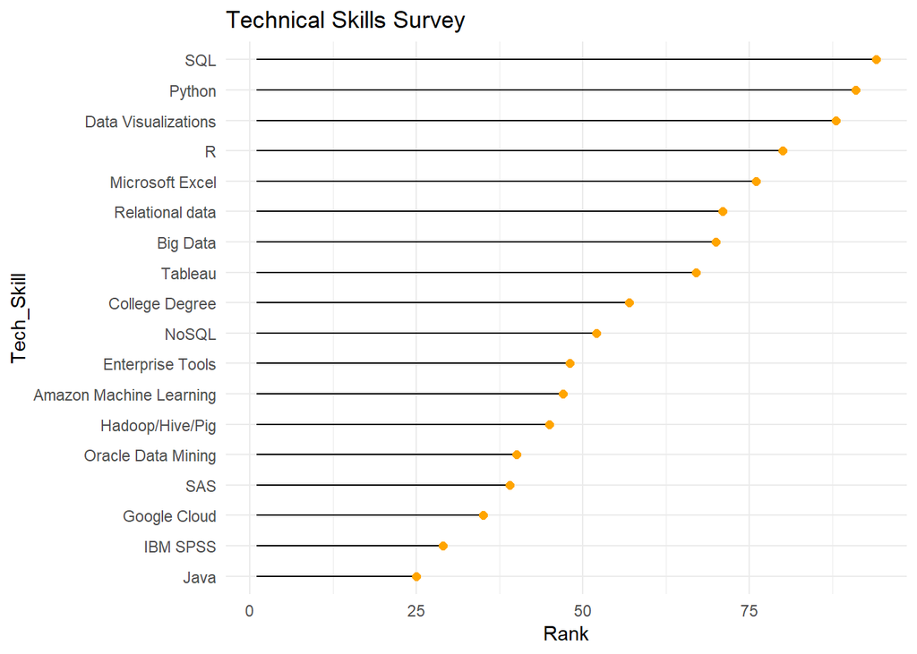

```r
#plot graph
scale %>%
  mutate(Tech_Skill = fct_reorder(Tech_Skill, Rank)) %>%
  ggplot( aes(x=Tech_Skill, y=Rank)) +
    geom_segment( aes(xend=Tech_Skill, yend=1)) +
    geom_point( size=2, color="orange") +
    coord_flip() + labs(title="Technical Skills Survey")+
    theme_minimal()
```

**Result**

From the Above analysis, we concluded that Top 5 Technical skills/tools are most important in the data science field are **SQL**, **Python**, **Data Visualizations**, **R** and **Microsoft Excel**.

## Soft Skills/tools needed to know as data scienticst

```r
softdata <- clean_rawData %>%
  select(`Intellectual curiosity`:`Generating Hypotheses`)

softdata<- na.omit(softdata)
softdata
```

|  | Intellectual curiosity | Business acumen | Communication skills | Teamwork | Collaboration | Creative Thinking | Problem Solving | Active Learning | Perceptiveness | Interpersonal Skills | Generating Hypotheses |
| --- | --- | --- | --- | --- | --- | --- | --- | --- | --- | --- | --- |
| 1 | 5 | 3 | 4 | 3 | 4 | 5 | 4 | 4 | 5 | 5 | 5 |
| 3 | 5 | 5 | 5 | 5 | 5 | 5 | 5 | 5 | 5 | 5 | 5 |
| 4 | 5 | 5 | 5 | 5 | 3 | 5 | 4 | 4 | 3 | 5 | 4 |
| 5 | 5 | 5 | 5 | 5 | 5 | 5 | 5 | 5 | 5 | 5 | 5 |
| 6 | 5 | 5 | 5 | 5 | 5 | 3 | 4 | 4 | 5 | 5 | 3 |
| 7 | 5 | 5 | 5 | 5 | 5 | 5 | 5 | 5 | 5 | 5 | 5 |
| 8 | 5 | 5 | 5 | 5 | 5 | 3 | 4 | 5 | 3 | 2 | 3 |
| 10 | 4 | 5 | 5 | 5 | 3 | 5 | 4 | 2 | 2 | 5 | 5 |
| 11 | 4 | 5 | 5 | 4 | 4 | 5 | 5 | 4 | 5 | 5 | 5 |
| 12 | 5 | 5 | 5 | 3 | 3 | 4 | 4 | 5 | 4 | 3 | 5 |

[output cut: 44 more lines]

```r
temp3 <- names(softdata)
temp4<- data.frame(matrix(unlist(colSums(softdata)), byrow=T))

scale1 <- cbind(temp3,temp4)
names(scale1)[1] <-"Soft_skill"
names(scale1)[2] <-"Total"

scale1 <- scale1 %>%
  arrange(desc(Total))
scale1
```

| Soft_skill | Total |
| --- | --- |
| Communication skills | 255 |
| Problem Solving | 253 |
| Intellectual curiosity | 247 |
| Business acumen | 244 |
| Creative Thinking | 239 |
| Generating Hypotheses | 230 |
| Active Learning | 229 |
| Perceptiveness | 229 |
| Interpersonal Skills | 225 |
| Collaboration | 212 |

[output cut: 1 more lines]

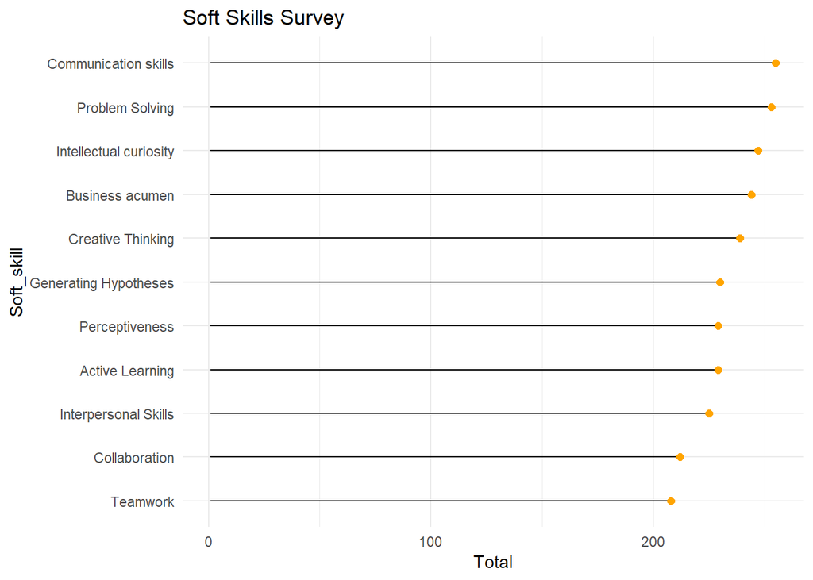

```r
#plot graph

scale1 %>%
  mutate(Soft_skill = fct_reorder(Soft_skill, Total)) %>%
  ggplot( aes(x=Soft_skill, y=Total)) +
    geom_segment( aes(xend=Soft_skill, yend=1)) +
    geom_point( size=2, color="orange") +
    coord_flip() + labs(title="Soft Skills Survey")+
    theme_minimal()
```

**Result**

From the Above analysis, we concluded that Top 5 soft skills/tools are most important in the data science field are **Communication skills, Problem Solving, Intellectual curiosity, Business acumen and Creative Thinking**.

# **Conclusion**

There is so much to learn from this project. I have learned How to conduct survey. Use the data, in your analysis. In my findings, **Python** is most recommended programming language for Data Scientist. Top 5 Technical skills/tools are most important in the data science field are **SQL**, **Python**, **Data Visualizations tools**, **R** and **Microsoft Excel**. and Five soft skills/tools are most important in the data science field are **Communication skills**, **Problem Solving**, **Intellectual curiosity**, **Business acumen** and **Creative Thinking**.

# **Reference**

1. The R-Graph Gallery For likert type Chart [LINK] https://www.r-graph-gallery.com/202-barplot-for-likert-type-items/
2. Kaggle ML and Data Science Survey, 2017 [LINK] https://www.kaggle.com/kaggle/kaggle-survey-2017
3. Platform used for survey
- Google Form
- linkedin.com
- Data Camp